# ML_LogisticRegression_044sgy

## 1.乳腺癌数据集：拆分代码，理解分类过程

```python
# 导入逻辑回归模型
from sklearn.linear_model import LogisticRegression as LR
# 导入乳腺癌数据集
from sklearn.datasets import load_breast_cancer
# 导入NumPy库
import numpy as np
# 导入matplotlib的pyplot模块用于绘图
import matplotlib.pyplot as plt
# 导入用于分割数据集为训练集和测试集的函数
from sklearn.model_selection import train_test_split
# 导入用于计算准确率的函数
from sklearn.metrics import accuracy_score
# 导入pandas库并将其命名为pd
import pandas as pd
```

```python
# 加载乳腺癌数据集
data = load_breast_cancer()
data.data.shape # 查看数据的形状大小
```

```
(569, 30)
```

```python
# 查看data的结构和描述性信息
data_keys = data.keys() # 获取 data 对象中所有键（key）的列表。在一个类似字典的对象中，键是可以用来访问其对应值的标识符。
data_feature_names = data.feature_names # 获取data 对象中 'feature_names' 属性的值，它是一个数组，包含数据集中所有特征的名称。
data_target_names = data.target_names # 获取 data 对象中 'target_names' 属性的值，这是一个数组，包含了目标变量（即分类标签）的描述性名称。

(data_keys, data_feature_names, data_target_names)  # 显示上面三者数据
```

```
(dict_keys(['data', 'target', 'frame', 'target_names', 'DESCR', 'feature_names', 'filename', 'data_module']),
 array(['mean radius', 'mean texture', 'mean perimeter', 'mean area',
        'mean smoothness', 'mean compactness', 'mean concavity',
        'mean concave points', 'mean symmetry', 'mean fractal dimension',
        'radius error', 'texture error', 'perimeter error', 'area error',
        'smoothness error', 'compactness error', 'concavity error',
        'concave points error', 'symmetry error',
        'fractal dimension error', 'worst radius', 'worst texture',
        'worst perimeter', 'worst area', 'worst smoothness',
        'worst compactness', 'worst concavity', 'worst concave points',
        'worst symmetry', 'worst fractal dimension'], dtype='<U23'),
 array(['malignant', 'benign'], dtype='<U9'))
```

```python
# 显示前几个特征数据实例
print("First five rows of data:\n", data.data[:5])

# 显示对应的前几个目标变量（标签）
print("First five targets:\n", data.target[:5])
```

```
First five rows of data:
 [[1.799e+01 1.038e+01 1.228e+02 1.001e+03 1.184e-01 2.776e-01 3.001e-01
  1.471e-01 2.419e-01 7.871e-02 1.095e+00 9.053e-01 8.589e+00 1.534e+02
  6.399e-03 4.904e-02 5.373e-02 1.587e-02 3.003e-02 6.193e-03 2.538e+01
  1.733e+01 1.846e+02 2.019e+03 1.622e-01 6.656e-01 7.119e-01 2.654e-01
  4.601e-01 1.189e-01]
 [2.057e+01 1.777e+01 1.329e+02 1.326e+03 8.474e-02 7.864e-02 8.690e-02
  7.017e-02 1.812e-01 5.667e-02 5.435e-01 7.339e-01 3.398e+00 7.408e+01
  5.225e-03 1.308e-02 1.860e-02 1.340e-02 1.389e-02 3.532e-03 2.499e+01
  2.341e+01 1.588e+02 1.956e+03 1.238e-01 1.866e-01 2.416e-01 1.860e-01
  2.750e-01 8.902e-02]
 [1.969e+01 2.125e+01 1.300e+02 1.203e+03 1.096e-01 1.599e-01 1.974e-01
  1.279e-01 2.069e-01 5.999e-02 7.456e-01 7.869e-01 4.585e+00 9.403e+01
  6.150e-03 4.006e-02 3.832e-02 2.058e-02 2.250e-02 4.571e-03 2.357e+01
  2.553e+01 1.525e+02 1.709e+03 1.444e-01 4.245e-01 4.504e-01 2.430e-01
  3.613e-01 8.758e-02]
 [1.142e+01 2.038e+01 7.758e+01 3.861e+02 1.425e-01 2.839e-01 2.414e-01
  1.052e-01 2.597e-01 9.744e-02 4.956e-01 1.156e+00 3.445e+00 2.723e+01
  9.110e-03 7.458e-02 5.661e-02 1.867e-02 5.963e-02 9.208e-03 1.491e+01
  2.650e+01 9.887e+01 5.677e+02 2.098e-01 8.663e-01 6.869e-01 2.575e-01
  6.638e-01 1.730e-01]
 [2.029e+01 1.434e+01 1.351e+02 1.297e+03 1.003e-01 1.328e-01 1.980e-01
  1.043e-01 1.809e-01 5.883e-02 7.572e-01 7.813e-01 5.438e+00 9.444e+01
  1.149e-02 2.461e-02 5.688e-02 1.885e-02 1.756e-02 5.115e-03 2.254e+01
  1.667e+01 1.522e+02 1.575e+03 1.374e-01 2.050e-01 4.000e-01 1.625e-01
  2.364e-01 7.678e-02]]
First five targets:
 [0 0 0 0 0]
```

```python
# 获取特征数据
X = data.data
pd.DataFrame(X)
```

|  | 0 | 1 | 2 | 3 | 4 | 5 | 6 | 7 | 8 | 9 | ... | 20 | 21 | 22 | 23 | 24 | 25 | 26 | 27 | 28 | 29 |
| --- | --- | --- | --- | --- | --- | --- | --- | --- | --- | --- | --- | --- | --- | --- | --- | --- | --- | --- | --- | --- | --- |
| 0 | 17.99 | 10.38 | 122.80 | 1001.0 | 0.11840 | 0.27760 | 0.30010 | 0.14710 | 0.2419 | 0.07871 | ... | 25.380 | 17.33 | 184.60 | 2019.0 | 0.16220 | 0.66560 | 0.7119 | 0.2654 | 0.4601 | 0.11890 |
| 1 | 20.57 | 17.77 | 132.90 | 1326.0 | 0.08474 | 0.07864 | 0.08690 | 0.07017 | 0.1812 | 0.05667 | ... | 24.990 | 23.41 | 158.80 | 1956.0 | 0.12380 | 0.18660 | 0.2416 | 0.1860 | 0.2750 | 0.08902 |
| 2 | 19.69 | 21.25 | 130.00 | 1203.0 | 0.10960 | 0.15990 | 0.19740 | 0.12790 | 0.2069 | 0.05999 | ... | 23.570 | 25.53 | 152.50 | 1709.0 | 0.14440 | 0.42450 | 0.4504 | 0.2430 | 0.3613 | 0.08758 |
| 3 | 11.42 | 20.38 | 77.58 | 386.1 | 0.14250 | 0.28390 | 0.24140 | 0.10520 | 0.2597 | 0.09744 | ... | 14.910 | 26.50 | 98.87 | 567.7 | 0.20980 | 0.86630 | 0.6869 | 0.2575 | 0.6638 | 0.17300 |
| 4 | 20.29 | 14.34 | 135.10 | 1297.0 | 0.10030 | 0.13280 | 0.19800 | 0.10430 | 0.1809 | 0.05883 | ... | 22.540 | 16.67 | 152.20 | 1575.0 | 0.13740 | 0.20500 | 0.4000 | 0.1625 | 0.2364 | 0.07678 |
| ... | ... | ... | ... | ... | ... | ... | ... | ... | ... | ... | ... | ... | ... | ... | ... | ... | ... | ... | ... | ... | ... |
| 564 | 21.56 | 22.39 | 142.00 | 1479.0 | 0.11100 | 0.11590 | 0.24390 | 0.13890 | 0.1726 | 0.05623 | ... | 25.450 | 26.40 | 166.10 | 2027.0 | 0.14100 | 0.21130 | 0.4107 | 0.2216 | 0.2060 | 0.07115 |
| 565 | 20.13 | 28.25 | 131.20 | 1261.0 | 0.09780 | 0.10340 | 0.14400 | 0.09791 | 0.1752 | 0.05533 | ... | 23.690 | 38.25 | 155.00 | 1731.0 | 0.11660 | 0.19220 | 0.3215 | 0.1628 | 0.2572 | 0.06637 |
| 566 | 16.60 | 28.08 | 108.30 | 858.1 | 0.08455 | 0.10230 | 0.09251 | 0.05302 | 0.1590 | 0.05648 | ... | 18.980 | 34.12 | 126.70 | 1124.0 | 0.11390 | 0.30940 | 0.3403 | 0.1418 | 0.2218 | 0.07820 |
| 567 | 20.60 | 29.33 | 140.10 | 1265.0 | 0.11780 | 0.27700 | 0.35140 | 0.15200 | 0.2397 | 0.07016 | ... | 25.740 | 39.42 | 184.60 | 1821.0 | 0.16500 | 0.86810 | 0.9387 | 0.2650 | 0.4087 | 0.12400 |
| 568 | 7.76 | 24.54 | 47.92 | 181.0 | 0.05263 | 0.04362 | 0.00000 | 0.00000 | 0.1587 | 0.05884 | ... | 9.456 | 30.37 | 59.16 | 268.6 | 0.08996 | 0.06444 | 0.0000 | 0.0000 | 0.2871 | 0.07039 |

569 rows × 30 columns

```python
# 获取目标数据（标签）
y = data.target
# 获取目标数据（标签）的数量
target_data_count = y.shape[0]

(y,target_data_count) #显示总共有569个目标数据（即标签）
```

```
(array([0, 0, 0, 0, 0, 0, 0, 0, 0, 0, 0, 0, 0, 0, 0, 0, 0, 0, 0, 1, 1, 1,
        0, 0, 0, 0, 0, 0, 0, 0, 0, 0, 0, 0, 0, 0, 0, 1, 0, 0, 0, 0, 0, 0,
        0, 0, 1, 0, 1, 1, 1, 1, 1, 0, 0, 1, 0, 0, 1, 1, 1, 1, 0, 1, 0, 0,
        1, 1, 1, 1, 0, 1, 0, 0, 1, 0, 1, 0, 0, 1, 1, 1, 0, 0, 1, 0, 0, 0,
        1, 1, 1, 0, 1, 1, 0, 0, 1, 1, 1, 0, 0, 1, 1, 1, 1, 0, 1, 1, 0, 1,
        1, 1, 1, 1, 1, 1, 1, 0, 0, 0, 1, 0, 0, 1, 1, 1, 0, 0, 1, 0, 1, 0,
        0, 1, 0, 0, 1, 1, 0, 1, 1, 0, 1, 1, 1, 1, 0, 1, 1, 1, 1, 1, 1, 1,
        1, 1, 0, 1, 1, 1, 1, 0, 0, 1, 0, 1, 1, 0, 0, 1, 1, 0, 0, 1, 1, 1,
        1, 0, 1, 1, 0, 0, 0, 1, 0, 1, 0, 1, 1, 1, 0, 1, 1, 0, 0, 1, 0, 0,
        0, 0, 1, 0, 0, 0, 1, 0, 1, 0, 1, 1, 0, 1, 0, 0, 0, 0, 1, 1, 0, 0,
        1, 1, 1, 0, 1, 1, 1, 1, 1, 0, 0, 1, 1, 0, 1, 1, 0, 0, 1, 0, 1, 1,
        1, 1, 0, 1, 1, 1, 1, 1, 0, 1, 0, 0, 0, 0, 0, 0, 0, 0, 0, 0, 0, 0,
        0, 0, 1, 1, 1, 1, 1, 1, 0, 1, 0, 1, 1, 0, 1, 1, 0, 1, 0, 0, 1, 1,
        1, 1, 1, 1, 1, 1, 1, 1, 1, 1, 1, 0, 1, 1, 0, 1, 0, 1, 1, 1, 1, 1,
        1, 1, 1, 1, 1, 1, 1, 1, 1, 0, 1, 1, 1, 0, 1, 0, 1, 1, 1, 1, 0, 0,
        0, 1, 1, 1, 1, 0, 1, 0, 1, 0, 1, 1, 1, 0, 1, 1, 1, 1, 1, 1, 1, 0,
        0, 0, 1, 1, 1, 1, 1, 1, 1, 1, 1, 1, 1, 0, 0, 1, 0, 0, 0, 1, 0, 0,
        1, 1, 1, 1, 1, 0, 1, 1, 1, 1, 1, 0, 1, 1, 1, 0, 1, 1, 0, 0, 1, 1,
        1, 1, 1, 1, 0, 1, 1, 1, 1, 1, 1, 1, 0, 1, 1, 1, 1, 1, 0, 1, 1, 0,
        1, 1, 1, 1, 1, 1, 1, 1, 1, 1, 1, 1, 0, 1, 0, 0, 1, 0, 1, 1, 1, 1,
        1, 0, 1, 1, 0, 1, 0, 1, 1, 0, 1, 0, 1, 1, 1, 1, 1, 1, 1, 1, 0, 0,
        1, 1, 1, 1, 1, 1, 0, 1, 1, 1, 1, 1, 1, 1, 1, 1, 1, 0, 1, 1, 1, 1,
        1, 1, 1, 0, 1, 0, 1, 1, 0, 1, 1, 1, 1, 1, 0, 0, 1, 0, 1, 0, 1, 1,
        1, 1, 1, 0, 1, 1, 0, 1, 0, 1, 0, 0, 1, 1, 1, 0, 1, 1, 1, 1, 1, 1,
        1, 1, 1, 1, 1, 0, 1, 0, 0, 1, 1, 1, 1, 1, 1, 1, 1, 1, 1, 1, 1, 1,
        1, 1, 1, 1, 1, 1, 1, 1, 1, 1, 1, 1, 0, 0, 0, 0, 0, 0, 1]),
 569)
```

```python
# 分割数据集，其中20%用作测试集，随机状态设置为1以确保每次分割都一样
Xtrain, Xtest, Ytrain, Ytest = train_test_split(X, y, test_size=0.2, random_state=1)

(Xtrain.shape,Xtest.shape,Ytrain.shape,Ytest.shape) # 显示划分的形状大小
```

```
((455, 30), (114, 30), (455,), (114,))
```

```python
pd.DataFrame(Xtrain) # 将特征变量Xtrain转换为DataFrame形式，以便快速查看数据
```

|  | 0 | 1 | 2 | 3 | 4 | 5 | 6 | 7 | 8 | 9 | ... | 20 | 21 | 22 | 23 | 24 | 25 | 26 | 27 | 28 | 29 |
| --- | --- | --- | --- | --- | --- | --- | --- | --- | --- | --- | --- | --- | --- | --- | --- | --- | --- | --- | --- | --- | --- |
| 0 | 17.99 | 20.66 | 117.80 | 991.7 | 0.10360 | 0.13040 | 0.120100 | 0.088240 | 0.1992 | 0.06069 | ... | 21.080 | 25.41 | 138.10 | 1349.0 | 0.14820 | 0.37350 | 0.33010 | 0.19740 | 0.3060 | 0.08503 |
| 1 | 20.29 | 14.34 | 135.10 | 1297.0 | 0.10030 | 0.13280 | 0.198000 | 0.104300 | 0.1809 | 0.05883 | ... | 22.540 | 16.67 | 152.20 | 1575.0 | 0.13740 | 0.20500 | 0.40000 | 0.16250 | 0.2364 | 0.07678 |
| 2 | 9.00 | 14.40 | 56.36 | 246.3 | 0.07005 | 0.03116 | 0.003681 | 0.003472 | 0.1788 | 0.06833 | ... | 9.699 | 20.07 | 60.90 | 285.5 | 0.09861 | 0.05232 | 0.01472 | 0.01389 | 0.2991 | 0.07804 |
| 3 | 12.21 | 14.09 | 78.78 | 462.0 | 0.08108 | 0.07823 | 0.068390 | 0.025340 | 0.1646 | 0.06154 | ... | 13.130 | 19.29 | 87.65 | 529.9 | 0.10260 | 0.24310 | 0.30760 | 0.09140 | 0.2677 | 0.08824 |
| 4 | 12.34 | 14.95 | 78.29 | 469.1 | 0.08682 | 0.04571 | 0.021090 | 0.020540 | 0.1571 | 0.05708 | ... | 13.180 | 16.85 | 84.11 | 533.1 | 0.10480 | 0.06744 | 0.04921 | 0.04793 | 0.2298 | 0.05974 |
| ... | ... | ... | ... | ... | ... | ... | ... | ... | ... | ... | ... | ... | ... | ... | ... | ... | ... | ... | ... | ... | ... |
| 450 | 19.79 | 25.12 | 130.40 | 1192.0 | 0.10150 | 0.15890 | 0.254500 | 0.114900 | 0.2202 | 0.06113 | ... | 22.630 | 33.58 | 148.70 | 1589.0 | 0.12750 | 0.38610 | 0.56730 | 0.17320 | 0.3305 | 0.08465 |
| 451 | 10.75 | 14.97 | 68.26 | 355.3 | 0.07793 | 0.05139 | 0.022510 | 0.007875 | 0.1399 | 0.05688 | ... | 11.950 | 20.72 | 77.79 | 441.2 | 0.10760 | 0.12230 | 0.09755 | 0.03413 | 0.2300 | 0.06769 |
| 452 | 17.20 | 24.52 | 114.20 | 929.4 | 0.10710 | 0.18300 | 0.169200 | 0.079440 | 0.1927 | 0.06487 | ... | 23.320 | 33.82 | 151.60 | 1681.0 | 0.15850 | 0.73940 | 0.65660 | 0.18990 | 0.3313 | 0.13390 |
| 453 | 14.03 | 21.25 | 89.79 | 603.4 | 0.09070 | 0.06945 | 0.014620 | 0.018960 | 0.1517 | 0.05835 | ... | 15.330 | 30.28 | 98.27 | 715.5 | 0.12870 | 0.15130 | 0.06231 | 0.07963 | 0.2226 | 0.07617 |
| 454 | 13.03 | 18.42 | 82.61 | 523.8 | 0.08983 | 0.03766 | 0.025620 | 0.029230 | 0.1467 | 0.05863 | ... | 13.300 | 22.81 | 84.46 | 545.9 | 0.09701 | 0.04619 | 0.04833 | 0.05013 | 0.1987 | 0.06169 |

455 rows × 30 columns

```python
# 创建逻辑回归模型，使用L1正则化，liblinear求解器，正则化强度为0.5，迭代1000次
lrl1 = LR(penalty="l1", solver="liblinear", C=0.5, max_iter=1000).fit(Xtrain, Ytrain)
lrl1
```

```
LogisticRegression(C=0.5, max_iter=1000, penalty='l1', solver='liblinear')
```

```python
lrl1.predict(Xtest) # 显示预测后的数据
```

```
array([1, 0, 1, 0, 0, 0, 0, 0, 1, 1, 1, 0, 0, 1, 1, 1, 1, 1, 1, 0, 1, 1,
       0, 1, 0, 1, 1, 0, 0, 0, 0, 1, 0, 0, 1, 1, 0, 1, 1, 1, 1, 1, 1, 1,
       1, 0, 1, 1, 1, 0, 0, 0, 1, 1, 1, 1, 1, 0, 1, 1, 1, 0, 1, 0, 1, 1,
       1, 0, 1, 1, 1, 1, 1, 0, 1, 0, 1, 1, 1, 0, 1, 0, 1, 0, 1, 1, 0, 1,
       0, 1, 1, 0, 1, 1, 0, 0, 1, 1, 1, 1, 1, 1, 1, 1, 1, 1, 1, 1, 0, 0,
       1, 1, 1, 1])
```

```python
Ytest # 显示目标数据，可以先肉眼与上预测的数据进行比较
```

```
array([1, 0, 1, 0, 0, 0, 0, 0, 1, 1, 1, 0, 0, 1, 1, 1, 1, 1, 1, 0, 1, 1,
       0, 1, 0, 1, 1, 0, 0, 0, 0, 1, 0, 0, 1, 1, 0, 1, 0, 1, 1, 1, 1, 1,
       1, 0, 1, 1, 1, 0, 0, 0, 1, 1, 1, 1, 1, 0, 1, 1, 1, 0, 1, 1, 1, 1,
       1, 0, 1, 1, 1, 1, 0, 0, 1, 0, 0, 0, 1, 0, 1, 0, 1, 0, 1, 1, 0, 1,
       0, 1, 1, 0, 1, 1, 0, 0, 1, 1, 1, 1, 1, 1, 1, 1, 1, 1, 1, 1, 0, 0,
       0, 1, 1, 1])
```

```python
# 对测试集进行预测并计算准确率
accuracy_score(lrl1.predict(Xtest), Ytest)
```

```
0.9473684210526315
```

### 1.1利用模型的接口predict_proba查看每个样本对应每个标签的概率

```python
# 使用predict_proba获取每个样本对应每个标签的概率
probabilities = lrl1.predict_proba(Xtest)
print(probabilities[:5])  # 先显示前5个样本的概率，便于理解,第一列表示0的概率，第二列表示1的概率
print("所有样本每个标签的概率显示：\n",probabilities)
```

```
[[2.78480692e-01 7.21519308e-01]
 [5.68246034e-01 4.31753966e-01]
 [2.96334859e-03 9.97036651e-01]
 [9.99083528e-01 9.16472182e-04]
 [8.83087725e-01 1.16912275e-01]]
所有样本每个标签的概率显示：
 [[2.78480692e-01 7.21519308e-01]
 [5.68246034e-01 4.31753966e-01]
 [2.96334859e-03 9.97036651e-01]
 [9.99083528e-01 9.16472182e-04]
 [8.83087725e-01 1.16912275e-01]
 [9.98631951e-01 1.36804915e-03]
 [9.99929253e-01 7.07473555e-05]
 [9.82915731e-01 1.70842692e-02]
 [1.10032987e-02 9.88996701e-01]
 [9.08687777e-03 9.90913122e-01]
 [1.06706926e-02 9.89329307e-01]
 [8.35155769e-01 1.64844231e-01]
 [9.15240333e-01 8.47596672e-02]
 [6.69434351e-03 9.93305656e-01]
 [3.13848093e-01 6.86151907e-01]
 [1.18671689e-01 8.81328311e-01]
 [1.66278791e-02 9.83372121e-01]
 [2.09030533e-02 9.79096947e-01]
 [4.39964723e-03 9.95600353e-01]
 [9.99999124e-01 8.75779990e-07]
 [6.60521774e-03 9.93394782e-01]
 [3.19981309e-02 9.68001869e-01]
 [9.98894716e-01 1.10528353e-03]
 [1.94435201e-02 9.80556480e-01]
 [9.35234457e-01 6.47655428e-02]
 [6.83553778e-02 9.31644622e-01]
 [7.70178035e-02 9.22982197e-01]
 [9.99998970e-01 1.02971509e-06]
 [1.00000000e+00 4.20117272e-19]
 [9.94363330e-01 5.63666980e-03]
 [9.99999999e-01 6.70533960e-10]
 [3.17756425e-03 9.96822436e-01]
 [9.99967907e-01 3.20928381e-05]
 [8.85620660e-01 1.14379340e-01]
```

[output cut: 65 more lines]

```
 [1.41100760e-02 9.85889924e-01]
 [5.35297676e-02 9.46470232e-01]
 [1.32040669e-02 9.86795933e-01]
 [5.45740878e-03 9.94542591e-01]
 [2.19368294e-01 7.80631706e-01]
 [6.31606594e-02 9.36839341e-01]
 [1.70827912e-02 9.82917209e-01]
 [2.21665834e-03 9.97783342e-01]
 [1.90320745e-03 9.98096793e-01]
 [9.76897189e-01 2.31028108e-02]
 [9.84791331e-01 1.52086694e-02]
 [3.17629313e-01 6.82370687e-01]
 [3.36031944e-02 9.66396806e-01]
 [4.19110349e-01 5.80889651e-01]
 [8.92724259e-03 9.91072757e-01]]
```

### 1.2使用模型的属性n_iter_查看实际迭代次数，查看参数coef_的值，对比L1与L2正则化的coef_值

```python
lrl1.n_iter_ # 查看模型lrl1的实际迭代次数
```

```
array([97], dtype=int32)
```

#### 逻辑回归模型lrl1, 在训练过程中实际迭代了97次，才达到收敛的条件或完成训练。这是在指定最多迭代1000次的情况下得到的结果

```python
lrl1.coef_   # 在逻辑回归模型中，这些系数与特征变量相乘，是决定决策边界的关键因素。
             #对于二分类问题，coef_ 是一个一维数组，其中的每个元素都对应于数据集中每个特征的系数。
```

```
array([[ 2.50532509,  0.        , -0.07450104, -0.00322133,  0.        ,
         0.        ,  0.        ,  0.        ,  0.        ,  0.        ,
         0.        ,  0.        ,  0.        , -0.03113694,  0.        ,
         0.        ,  0.        ,  0.        ,  0.        ,  0.        ,
         0.99119909, -0.15536295, -0.16293117, -0.02383808,  0.        ,
         0.        , -1.44780714,  0.        ,  0.        ,  0.        ]])
```

```python
lrl1.coef_.shape # 显示其形状
```

```
(1, 30)
```

```python
# 创建逻辑回归模型，使用L2正则化，liblinear求解器，正则化强度为0.5，迭代1000次
lrl2 = LR(penalty="l2", solver="liblinear", C=0.5, max_iter=1000).fit(Xtrain, Ytrain)
# 对测试集进行预测并计算准确率
accuracy_score(lrl2.predict(Xtest), Ytest)
```

```
0.9473684210526315
```

```python
lrl2.n_iter_  # 查看模型lrl2的实际迭代次数
```

```
array([21], dtype=int32)
```

#### 逻辑回归模型lrl2, 在训练过程中实际迭代了21次，就达到收敛的条件或完成训练。这是在指定最多迭代1000次的情况下得到的结果

```python
lrl2.coef_ # 查看模型lrl2参数coef_的值
```

```
array([[ 1.37025963e+00,  5.70455736e-02,  1.16474336e-02,
         1.14931919e-03, -5.05479199e-02, -2.40129650e-01,
        -3.58494260e-01, -1.54762190e-01, -7.81057232e-02,
        -1.07677965e-02,  6.79361486e-02,  3.69810248e-01,
         2.61856823e-01, -6.41645490e-02, -7.11755387e-03,
        -4.47666291e-02, -7.80610050e-02, -2.29624313e-02,
        -2.27522746e-02, -3.63193246e-03,  1.46301093e+00,
        -2.03893771e-01, -1.73507296e-01, -2.51277691e-02,
        -8.83420310e-02, -6.67438527e-01, -9.06682103e-01,
        -2.92356515e-01, -2.12169115e-01, -5.15903306e-02]])
```

```python
lrl2.coef_.shape # 显示其形状，与模型lrl1显示的排版不一样，但是大小是一样的
```

```
(1, 30)
```

（1）L2正则化（岭回归）和L1正则化（Lasso回归）都是用来控制过拟合的方法，它们通过在损失函数中添加惩罚项来限制模型的复杂度。在逻辑回归模型中，这些惩罚项会影响模型的coef_值，从而影响模型的拟合效果。

（2）L2正则化会使得coef_值趋向于较小的数值，但不会使其变为0。这意味着L2正则化能够减小特征的权重，从而降低模型对特定特征的过度依赖，有效地控制了模型的复杂度，减少了过拟合的风险。

（3）相比之下，L1正则化不仅能够减小特征的权重，还能将一些特征的权重变为0，从而实现特征的稀疏性。这意味着L1正则化能够更加有效地筛选出对模型预测贡献较小的特征，从而进一步降低模型的复杂度，减少了过拟合的风险。

### 1.3 划分数据集时将参数test_size由0.2改为0.5

```python
# 导入逻辑回归模型
from sklearn.linear_model import LogisticRegression as LR
# 导入乳腺癌数据集
from sklearn.datasets import load_breast_cancer
# 导入NumPy库
import numpy as np
# 导入matplotlib的pyplot模块用于绘图
import matplotlib.pyplot as plt
# 导入用于分割数据集为训练集和测试集的函数
from sklearn.model_selection import train_test_split
# 导入用于计算准确率的函数
from sklearn.metrics import accuracy_score
# 导入pandas库并将其命名为pd
import pandas as pd

# 加载乳腺癌数据集
data = load_breast_cancer()
# 获取特征数据
X = data.data
# 获取目标数据（标签）
y = data.target


# 分割数据集，其中分别用20%、50%用作测试集，随机状态设置为1以确保每次分割都一样
Xtrain1, Xtest1, Ytrain1, Ytest1 = train_test_split(X, y, test_size=0.2, random_state=1)
Xtrain2, Xtest2, Ytrain2, Ytest2 = train_test_split(X, y, test_size=0.5, random_state=1)


# 创建逻辑回归模型，使用L1正则化，liblinear求解器，正则化强度为0.5，迭代1000次
lrl1_1 = LR(penalty="l1", solver="liblinear", C=0.5, max_iter=1000).fit(Xtrain1, Ytrain1)
lrl1_2 = LR(penalty="l1", solver="liblinear", C=0.5, max_iter=1000).fit(Xtrain2, Ytrain2)

# 对测试集进行预测并计算准确率
print("test_size为0.2时的精确度：",accuracy_score(lrl1_1.predict(Xtest1), Ytest1))
print("test_size为0.5时的精确度：",accuracy_score(lrl1_2.predict(Xtest2), Ytest2))
```

```
test_size为0.2时的精确度： 0.9473684210526315
test_size为0.5时的精确度： 0.9228070175438596
```

划分数据集时将参数test_size由0.2改为0.5时，对比模型精确度的由0.9473684210526315变成了0.9228070175438596，有所下降，说明增加测试集的比例，减少了训练集的比例，导致模型训练的数据量减少，从而影响了模型的精确度。这也说明在划分数据集时，需要根据具体情况选择合适的测试集比例，以保证模型训练的数据量足够，并且测试集的数据量也足够用于评估模型的性能。

### 1.4 模型的参数solver的取值设定为“saga”

```python
# 创建逻辑回归模型，使用L1正则化，liblinear、saga求解器，正则化强度为0.5，迭代1000次
lrl1_11 = LR(penalty="l1", solver="liblinear", C=0.5, max_iter=1000).fit(Xtrain1, Ytrain1)
lrl1_12 = LR(penalty="l1", solver="saga", C=0.5, max_iter=1000).fit(Xtrain1, Ytrain1)


lrl1_21 = LR(penalty="l1", solver="liblinear", C=0.5, max_iter=1000).fit(Xtrain2, Ytrain2)
lrl1_22 = LR(penalty="l1", solver="saga", C=0.5, max_iter=1000).fit(Xtrain2, Ytrain2)

# 对测试集进行预测并计算准确率
print('test_size为0.2, solver="liblinear"时的精确度：',accuracy_score(lrl1_11.predict(Xtest1), Ytest1))
print('test_size为0.2, solver="saga"时的精确度：',accuracy_score(lrl1_12.predict(Xtest1), Ytest1))


print('test_size为0.5, solver="liblinear"时的精确度：',accuracy_score(lrl1_21.predict(Xtest2), Ytest2))
print('test_size为0.5, solver="saga"时的精确度：',accuracy_score(lrl1_22.predict(Xtest2), Ytest2))
```

```
test_size为0.2, solver="liblinear"时的精确度： 0.9473684210526315
test_size为0.2, solver="saga"时的精确度： 0.9298245614035088
test_size为0.5, solver="liblinear"时的精确度： 0.9228070175438596
test_size为0.5, solver="saga"时的精确度： 0.9017543859649123
```

（1）在这个数据集上，"liblinear" solver使用的是坐标轴下降法（Coordinate Descent），而"saga" solver使用的是随机平均梯度下降法（Stochastic Average Gradient Descent）。这两种算法在优化目标函数时的策略和计算方式不同，可能会对模型的性能产生影响。

（2）"liblinear" solver可能更适合处理较小的测试集，因为它可以更快地收敛并找到一个较好的解。而"saga" solver可能更适合处理较大的数据集，因为它可以更好地处理噪声和离群值，并且可以更好地避免陷入局部最优解。

（3）在实际应用中，我们需要根据具体的数据集和任务需求选择合适的solver参数，以获得最佳的模型性能。

### 1.5 模型的参数C的取值分别设定为0.2和0.8

```python
# 创建逻辑回归模型，使用L1正则化，liblinear\saga求解器，正则化强度为0.2、0.8，迭代1000次
lrl1_11 = LR(penalty="l1", solver="liblinear", C=0.2, max_iter=1000).fit(Xtrain1, Ytrain1)
lrl1_12 = LR(penalty="l1", solver="liblinear", C=0.8, max_iter=1000).fit(Xtrain1, Ytrain1)


lrl1_21 = LR(penalty="l1", solver="saga", C=0.2, max_iter=1000).fit(Xtrain1, Ytrain1)
lrl1_22 = LR(penalty="l1", solver="saga", C=0.8, max_iter=1000).fit(Xtrain1, Ytrain1)

# 对测试集进行预测并计算准确率
print('正则化强度为0.2, solver="liblinear"时的精确度：',accuracy_score(lrl1_11.predict(Xtest1), Ytest1))
print('正则化强度为为0.8, solver="liblinear"时的精确度：',accuracy_score(lrl1_12.predict(Xtest1), Ytest1))


print('正则化强度为0.2, solver="saga"时的精确度：',accuracy_score(lrl1_21.predict(Xtest1), Ytest1))
print('正则化强度为0.8, solver="saga"时的精确度：',accuracy_score(lrl1_22.predict(Xtest1), Ytest1))
```

```
正则化强度为0.2, solver="liblinear"时的精确度： 0.956140350877193
正则化强度为为0.8, solver="liblinear"时的精确度： 0.9649122807017544
正则化强度为0.2, solver="saga"时的精确度： 0.9298245614035088
正则化强度为0.8, solver="saga"时的精确度： 0.9298245614035088
```

### 1.6 画出模型在训练集和测试集上的表现随参数C变化的学习曲线，找到最优的C值

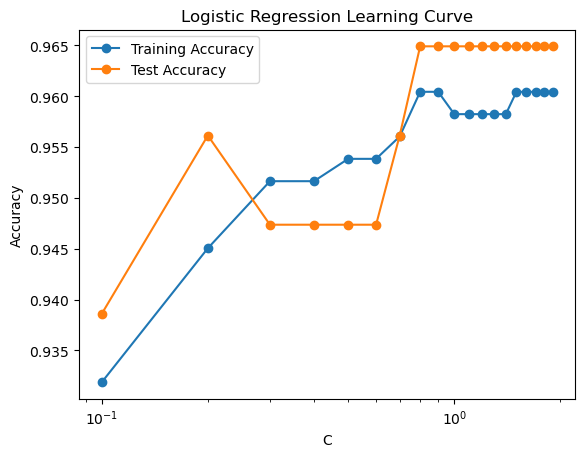

```
最优的C值为: 0.8
```

```python
# 导入逻辑回归模型
from sklearn.linear_model import LogisticRegression as LR
# 导入乳腺癌数据集
from sklearn.datasets import load_breast_cancer
# 导入NumPy库
import numpy as np
# 导入matplotlib的pyplot模块用于绘图
import matplotlib.pyplot as plt
# 导入用于分割数据集为训练集和测试集的函数
from sklearn.model_selection import train_test_split
# 导入用于计算准确率的函数
from sklearn.metrics import accuracy_score
# 导入pandas库并将其命名为pd
import pandas as pd

# 加载乳腺癌数据集
data = load_breast_cancer()
# 获取特征数据
X = data.data
# 获取目标数据（标签）
y = data.target




# 划分训练集和测试集
X_train, X_test, y_train, y_test = train_test_split(X, y, test_size=0.2, random_state=1)

# 不同的C值
C_values = np.arange(0.1,2,0.1)

# 用于存储训练集和测试集上的精确度
train_accuracy = []
test_accuracy = []

# 对每个C值训练模型并记录精确度
for C in C_values:
    model = LR(penalty="l1",C=C, solver='liblinear',max_iter=1000)
    model.fit(X_train, y_train)
    train_accuracy.append(model.score(X_train, y_train))  # 记录训练集上的精确度
    test_accuracy.append(model.score(X_test, y_test))  # 记录测试集上的精确度

# 绘制学习曲线
plt.figure()
plt.plot(C_values, train_accuracy, marker='o', label='Training Accuracy')  # 绘制训练集上的精确度
plt.plot(C_values, test_accuracy, marker='o', label='Test Accuracy')  # 绘制测试集上的精确度
plt.xscale('log')  # 使用对数尺度
plt.xlabel('C')  # x轴标签
plt.ylabel('Accuracy')  # y轴标签
plt.title('Logistic Regression Learning Curve')  # 图表标题
plt.legend()  # 添加图例
plt.show()

# 找到测试集精确度最高对应的C值作为最优的C值
best_C = C_values[np.argmax(test_accuracy)]
print("最优的C值为:", best_C)
```

## 2. 股票客户数据集

```python
# 从Excel文件加载数据文件加载股票客户数据集
data_stock = pd.read_excel('股票客户.xlsx',sheet_name='Sheet1')
```

```python
pd.DataFrame(data_stock) #查看大致数据和结构
```

|  | 账户资金（元） | 最后一次交易距今时间（天） | 上月交易佣金（元） | 累计交易佣金（元） | 本券商使用时长（年） | 是否流失 |
| --- | --- | --- | --- | --- | --- | --- |
| 0 | 22686.5 | 297 | 149.25 | 2029.85 | 0 | 0 |
| 1 | 190055.0 | 42 | 284.75 | 3889.50 | 2 | 0 |
| 2 | 29733.5 | 233 | 269.25 | 2108.15 | 0 | 1 |
| 3 | 185667.5 | 44 | 211.50 | 3840.75 | 3 | 0 |
| 4 | 33648.5 | 213 | 353.50 | 2151.65 | 0 | 1 |
| ... | ... | ... | ... | ... | ... | ... |
| 7038 | 199145.0 | 40 | 424.00 | 3990.50 | 1 | 0 |
| 7039 | 682661.0 | 1 | 516.00 | 9362.90 | 5 | 0 |
| 7040 | 51180.5 | 167 | 148.00 | 2346.45 | 0 | 0 |
| 7041 | 47594.0 | 174 | 372.00 | 2306.60 | 0 | 1 |
| 7042 | 636005.0 | 2 | 528.25 | 8844.50 | 5 | 0 |

7043 rows × 6 columns

```python
# 提取特征变量X_stock
X_stock = data_stock.drop('是否流失', axis=1)  # 删除'是否流失'列，剩下的就是特征变量
pd.DataFrame(X_stock)
```

|  | 账户资金（元） | 最后一次交易距今时间（天） | 上月交易佣金（元） | 累计交易佣金（元） | 本券商使用时长（年） |
| --- | --- | --- | --- | --- | --- |
| 0 | 22686.5 | 297 | 149.25 | 2029.85 | 0 |
| 1 | 190055.0 | 42 | 284.75 | 3889.50 | 2 |
| 2 | 29733.5 | 233 | 269.25 | 2108.15 | 0 |
| 3 | 185667.5 | 44 | 211.50 | 3840.75 | 3 |
| 4 | 33648.5 | 213 | 353.50 | 2151.65 | 0 |
| ... | ... | ... | ... | ... | ... |
| 7038 | 199145.0 | 40 | 424.00 | 3990.50 | 1 |
| 7039 | 682661.0 | 1 | 516.00 | 9362.90 | 5 |
| 7040 | 51180.5 | 167 | 148.00 | 2346.45 | 0 |
| 7041 | 47594.0 | 174 | 372.00 | 2306.60 | 0 |
| 7042 | 636005.0 | 2 | 528.25 | 8844.50 | 5 |

7043 rows × 5 columns

```python
# 提取目标变量
y_stock = data_stock['是否流失']  # 只保留'是否流失'列，这就是目标变量
pd.DataFrame(y_stock)
```

|  | 是否流失 |
| --- | --- |
| 0 | 0 |
| 1 | 0 |
| 2 | 1 |
| 3 | 0 |
| 4 | 1 |
| ... | ... |
| 7038 | 0 |
| 7039 | 0 |
| 7040 | 0 |
| 7041 | 1 |
| 7042 | 0 |

7043 rows × 1 columns

#### LR模型中penalty="l1",solver='liblinear',max_iter=1000，寻找最优参数C

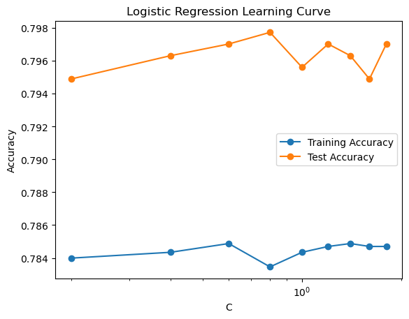

```
最优的C值为: 0.8
```

```python
# 划分训练集和测试集
X_train, X_test, y_train, y_test = train_test_split(X_stock, y_stock, test_size=0.2, random_state=1)

# 不同的C值
C_values = np.arange(0.2,2,0.2)

# 用于存储训练集和测试集上的精确度
train_accuracy = []
test_accuracy = []

# 对每个C值训练模型并记录精确度
for C in C_values:
    model = LR(penalty="l1",C=C, solver='liblinear',max_iter=1000)
    model.fit(X_train, y_train)
    train_accuracy.append(model.score(X_train, y_train))  # 记录训练集上的精确度
    test_accuracy.append(model.score(X_test, y_test))  # 记录测试集上的精确度

# 绘制学习曲线
plt.figure()
plt.plot(C_values, train_accuracy, marker='o', label='Training Accuracy')  # 绘制训练集上的精确度
plt.plot(C_values, test_accuracy, marker='o', label='Test Accuracy')  # 绘制测试集上的精确度
plt.xscale('log')  # 使用对数尺度
plt.xlabel('C')  # x轴标签
plt.ylabel('Accuracy')  # y轴标签
plt.title('Logistic Regression Learning Curve')  # 图表标题
plt.legend()  # 添加图例
plt.show()

# 找到测试集精确度最高对应的C值作为最优的C值
best_C = C_values[np.argmax(test_accuracy)]
print("最优的C值为:", best_C)
```

#### LR模型中penalty="l1",solver='saga',max_iter=1000，寻找最优参数C

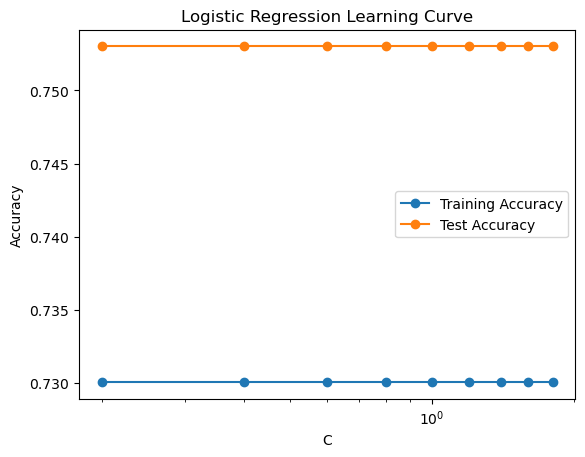

```
最优的C值为: 0.2
```

```python
# 划分训练集和测试集
X_train, X_test, y_train, y_test = train_test_split(X_stock, y_stock, test_size=0.2, random_state=1)

# 不同的C值
C_values = np.arange(0.2,2,0.2)

# 用于存储训练集和测试集上的精确度
train_accuracy = []
test_accuracy = []

# 对每个C值训练模型并记录精确度
for C in C_values:
    model = LR(penalty="l1",C=C, solver='saga',max_iter=1000)
    model.fit(X_train, y_train)
    train_accuracy.append(model.score(X_train, y_train))  # 记录训练集上的精确度
    test_accuracy.append(model.score(X_test, y_test))  # 记录测试集上的精确度

# 绘制学习曲线
plt.figure()
plt.plot(C_values, train_accuracy, marker='o', label='Training Accuracy')  # 绘制训练集上的精确度
plt.plot(C_values, test_accuracy, marker='o', label='Test Accuracy')  # 绘制测试集上的精确度
plt.xscale('log')  # 使用对数尺度
plt.xlabel('C')  # x轴标签
plt.ylabel('Accuracy')  # y轴标签
plt.title('Logistic Regression Learning Curve')  # 图表标题
plt.legend()  # 添加图例
plt.show()

# 找到测试集精确度最高对应的C值作为最优的C值
best_C = C_values[np.argmax(test_accuracy)]
print("最优的C值为:", best_C)
```

#### 因此，LR模型中penalty="l1",solver='liblinear',max_iter=1000表现更好，最优参数C为0.8

## 3. 乳腺癌数据集breast_cancer，在最优参数C下使用学习曲线寻找最佳迭代次数

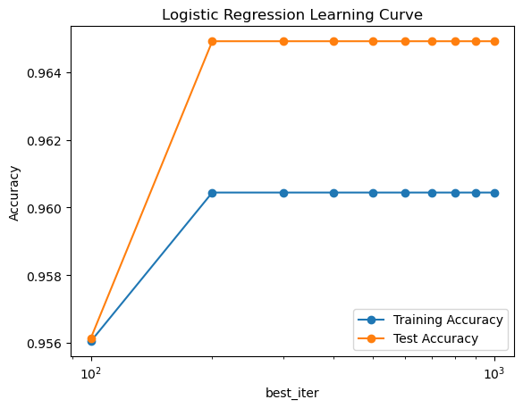

```
最优的C值为: 200
```

```python
# 加载乳腺癌数据集
data = load_breast_cancer()
# 获取特征数据
X = data.data
# 获取目标数据（标签）
y = data.target
# 划分训练集和测试集
X_train, X_test, y_train, y_test = train_test_split(X, y, test_size=0.2, random_state=1)

# 不同的最大迭代次数的值
max_values = np.arange(100,1001,100)

# 用于存储训练集和测试集上的精确度
train_accuracy = []
test_accuracy = []

# 对每个C值训练模型并记录精确度
for max_value in max_values:
    model = LR(penalty="l1",C=0.8, solver='liblinear',max_iter=max_value)
    model.fit(X_train, y_train)
    train_accuracy.append(model.score(X_train, y_train))  # 记录训练集上的精确度
    test_accuracy.append(model.score(X_test, y_test))  # 记录测试集上的精确度

# 绘制学习曲线
plt.figure()
plt.plot(max_values, train_accuracy, marker='o', label='Training Accuracy')  # 绘制训练集上的精确度
plt.plot(max_values, test_accuracy, marker='o', label='Test Accuracy')  # 绘制测试集上的精确度
plt.xscale('log')  # 使用对数尺度
plt.xlabel('best_iter')  # x轴标签
plt.ylabel('Accuracy')  # y轴标签
plt.title('Logistic Regression Learning Curve')  # 图表标题
plt.legend()  # 添加图例
plt.show()

# 找到测试集精确度最高对应的C值作为最优的C值
best_max_iter = max_values[np.argmax(test_accuracy)]
print("最优的C值为:", best_max_iter)
```

### 因此：针对乳腺癌数据集breast_cancer，根据最优参数C为0.8， LR模型中其他参数分别为penalty="l1",solver='liblinear',max_iter=1000，结合学习曲线可知最佳迭代次数有多个值，最少且最佳的迭代次为200。